# Stout_Case_Study

Ben Wagner

10/27/2021

```r
library(tidyverse)         # for graphing and data cleaning
library(tidymodels)        # for modeling
library(naniar)            # for analyzing missing values
library(vip)               # for variable importance plots
library(rsconnect)
library(purrr)
library(usemodels)         # for suggesting step_XXX() functions
library(glmnet)            # for regularized regression, including LASSO
library(stacks)
library(themis)
library(modelr)
```

## Case #1

```r
loans <- read_csv(file = 'loans_full_schema.csv')
```

Each row of the dataset represents an individual who recieved a loan from another person via the Lending Club. The data spans 3 months (January, February, March) of 2018, and contains important statistics regarding the individuals credit when paying back this loan. I don’t see any issues with the data other than the possibility that biases could be present in the predictive model of interest rate. I need to make sure that specific jobs, or underlying variables (race, gender) are not correlated with my model.

# Graph 1

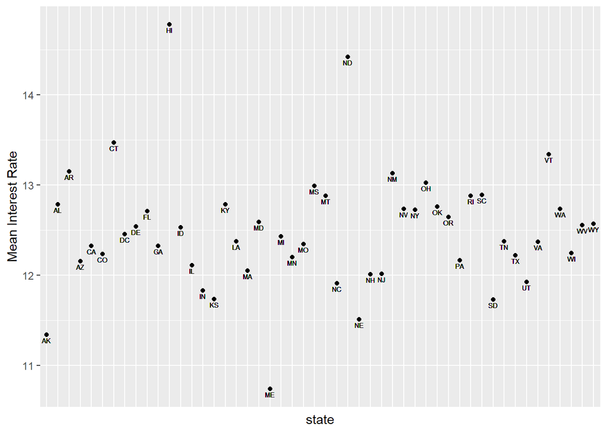

```r
loans %>%
  group_by(state) %>%
  mutate(mean_ir = mean(interest_rate)) %>%
  ggplot(aes(x= state, y= mean_ir)) +
  geom_point()+
  geom_text(aes(label=state), vjust= 1.5, size= 2)+
  labs(y= "Mean Interest Rate")+
  theme(axis.ticks.x = element_blank(),
        axis.text.x = element_blank())
```

You can see from this graph that the states Hawaii, North Dakota, and Connecticut are the states with the highest average interest rates. This leads me to question why those specific states have higher average interest rates. Nonetheless, there does not seem to be a clear trend between the geography of the state and interest rate.

#Graph 2

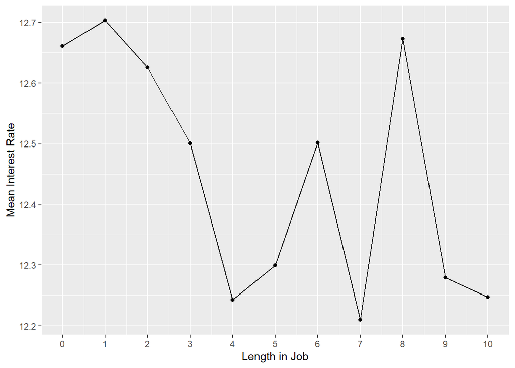

```r
loans %>%
  group_by(emp_length) %>%
  mutate(mean_ir = mean(interest_rate)) %>%
  ggplot(aes(x=emp_length, y=mean_ir))+
  geom_point()+
  geom_line()+
  labs(x="Length in Job", y= "Mean Interest Rate")+
  scale_x_continuous(breaks = (0:10))
```

If you look at this graph, you can see that the people who are newer to their job have higher average interest rates. This should be expected. However, people who have been at their jobs for 6 years and 8 years had unexpected high rates. This is most likely due to reasons not associated with time spent at their job, so we can assume that time on the job should be included in our model to predict interest rate.

#Graph 3

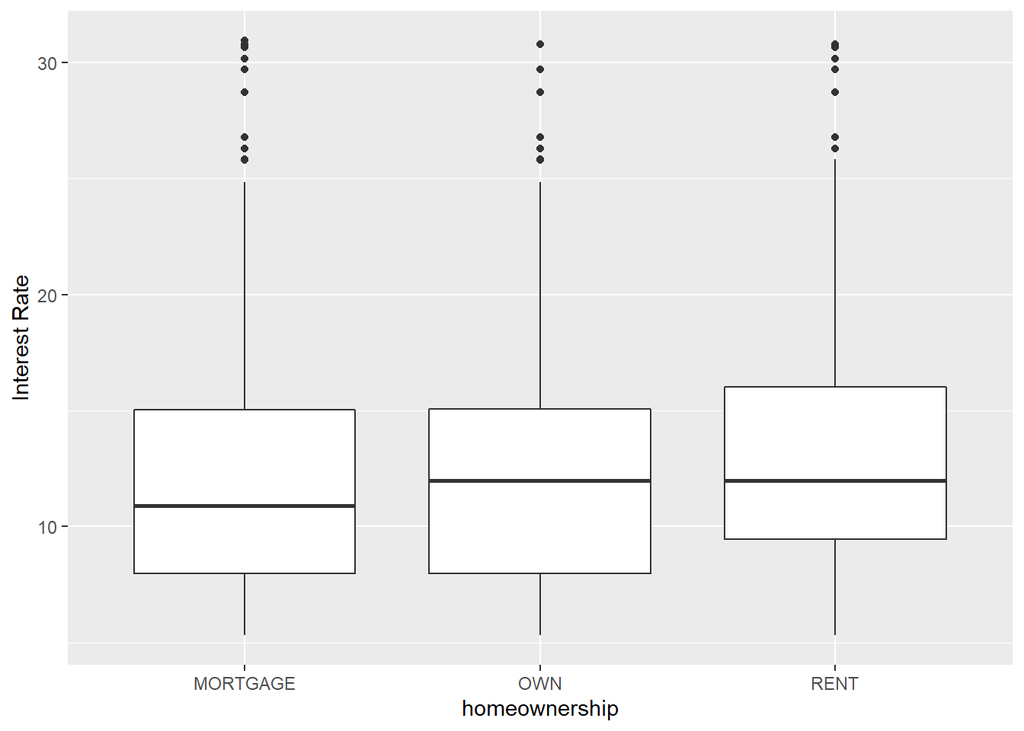

```r
loans %>%
  group_by(homeownership) %>%
  ggplot(aes(x=homeownership, y=interest_rate))+
  geom_boxplot()+
  labs(y="Interest Rate")
```

#Graph 4

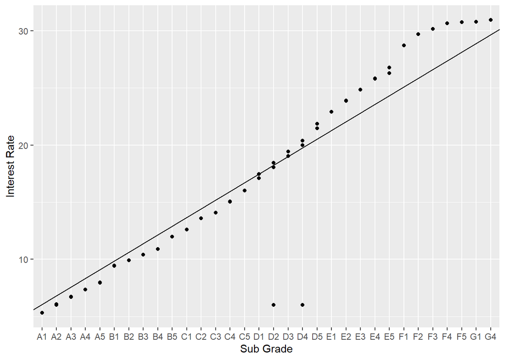

```r
sub_grade_lm <- lm(interest_rate ~ sub_grade, loans)
loans %>%
  #group_by(grade) %>%
  ggplot(aes(x=sub_grade, y=interest_rate)) +
  geom_point()+
  geom_abline(slope = coef(sub_grade_lm)[[2]], intercept = coef(sub_grade_lm)[[1]])+
  labs(x="Sub Grade", y="Interest Rate")
```

This graph looks at the different interest rates for each Sub Grades. I also created a linear regression to show the line of best fit for all the points on the graph. There is a strong positive trend between interest rate and sub grade. Thus Sub Grade should be a very important feature in our predictive model of interest rate.

#Graph 5

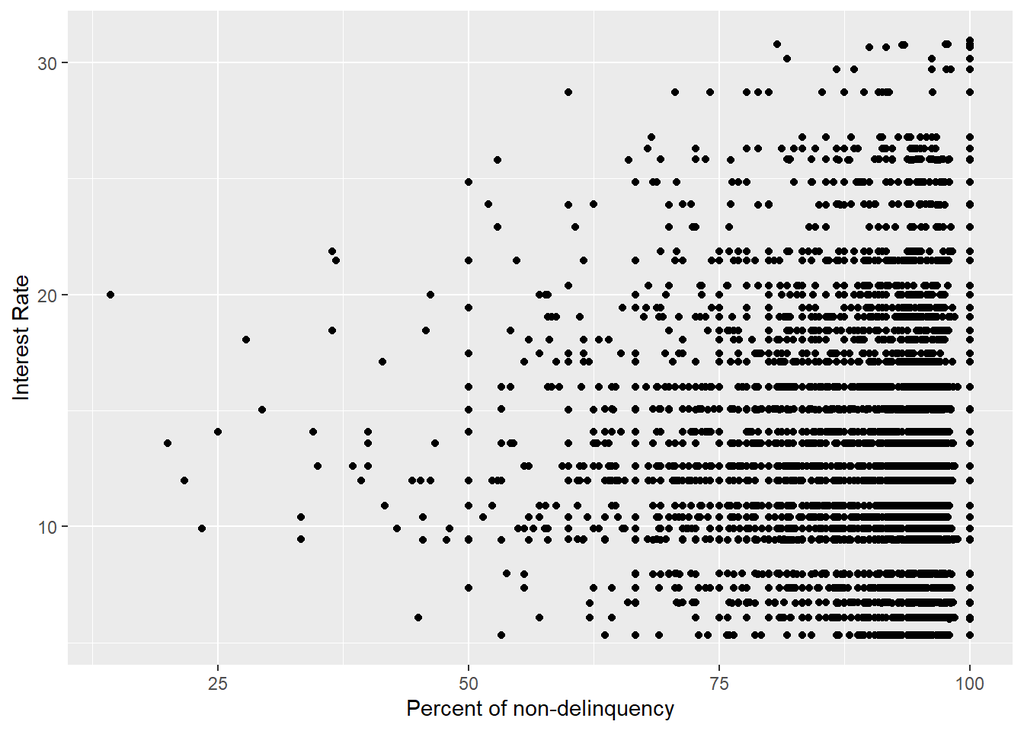

```r
loans %>%
  ggplot(aes(y=interest_rate, x=account_never_delinq_percent ))+
  geom_point()+
  labs(y="Interest Rate", x="Percent of non-delinquency")
```

Noticing from this graph is yes, individuals who had a higher percent of credit lines where they were never delinquent had lower interest rates. However, those that had a lower percentage of non-delinquent lines of credit also show lower interest rates. I would think those that are more typically delinquent, should have higher levels of interest because they are not reliable in paying back their loans.

```r
loans2 <- loans %>%
  filter(application_type == "individual") %>%
  select(-application_type, -annual_income_joint, -verification_income_joint, -debt_to_income_joint)


loans2
```

```
## # A tibble: 8,505 x 51
##    emp_title              emp_length state homeownership annual_income verified_income
##    <chr>                       <dbl> <chr> <chr>                 <dbl> <chr>
##  1 global config engineer          3 NJ    MORTGAGE              90000 Verified
##  2 warehouse office clerk         10 HI    RENT                  40000 Not Verified
##  3 assembly                        3 WI    RENT                  40000 Source Verified
##  4 customer service                1 PA    RENT                  30000 Not Verified
##  5 <NA>                           NA KY    OWN                   34000 Not Verified
##  6 police                         10 AZ    MORTGAGE             110000 Source Verified
##  7 parts                          10 NV    MORTGAGE              65000 Source Verified
##  8 4th person                      3 IL    RENT                  30000 Not Verified
##  9 supervisor                     10 IL    MORTGAGE              75000 Verified
## 10 register nurse                  2 FL    MORTGAGE              91900 Source Verified
## # ... with 8,495 more rows, and 45 more variables: debt_to_income <dbl>,
## #   delinq_2y <dbl>, months_since_last_delinq <dbl>,
## #   earliest_credit_line <dbl>, inquiries_last_12m <dbl>,
## #   total_credit_lines <dbl>, open_credit_lines <dbl>,
## #   total_credit_limit <dbl>, total_credit_utilized <dbl>,
## #   num_collections_last_12m <dbl>, num_historical_failed_to_pay <dbl>,
## #   months_since_90d_late <dbl>, current_accounts_delinq <dbl>, ...
```

```r
loans2 %>%
  add_n_miss() %>%
  count(n_miss_all)
```

```
## # A tibble: 6 x 2
##   n_miss_all     n
##        <int> <int>
## 1          0  1602
## 2          1  1613
## 3          2  4049
## 4          3   867
## 5          4   305
## 6          5    69
```

```r
set.seed(327) #for reproducibility

# Randomly assigns 75% of the data to training.
loans_split <- initial_split(loans2,
                             prop = .75)
loans_split
```

```
## <Analysis/Assess/Total>
## <6378/2127/8505>
```

```r
#<training/testing/total>

loans_training <- training(loans_split)
loans_testing <- testing(loans_split)
```

```r
loans_recipe <- recipe(interest_rate ~ .,
                       data = loans_training) %>%
  # Pre-processing:
  step_rm(emp_title, state, num_accounts_120d_past_due) %>%
  step_mutate_at(all_numeric(), fn= ~replace(., is.na(.), 0)) %>%
  #step_mutate_at(all_nominal(), fn= ~replace(., is.na(.), "Null")) %>%
  # Make these evaluative variables, not included in modeling
  update_role(all_of(c("emp_title",
                       "state",
                       "issue_month")),
              new_role = "evaluative") %>%
  # Create indicator variables for factors/character/nominal
  # explicitly remove outcome, even though outcome isn't nominal
  # this is important in cases when we have a nominal output (eg. logistic)
  step_dummy(all_nominal(),
             -all_outcomes(),
             -has_role(match = "evaluative")) %>%
  step_normalize(all_predictors(),
                 -all_nominal())
```

```r
loans_recipe %>%
  prep(loans_training) %>%
  juice()
```

```
## # A tibble: 6,378 x 99
##    emp_length annual_income debt_to_income delinq_2y months_since_last_delinq
##         <dbl>         <dbl>          <dbl>     <dbl>                    <dbl>
##  1      1.17         0.693          0.854     -0.311                  -0.691
##  2      1.17        -0.700          1.15      -0.311                  -0.691
##  3     -0.372        1.03           0.0334     2.61                   -0.431
##  4      1.17         0.264         -1.00       1.15                   -0.258
##  5     -1.40        -0.731         -1.82      -0.311                  -0.691
##  6     -0.114       -0.700          0.608     -0.311                   1.82
##  7     -1.14         0.264         -0.248      1.15                    0.262
##  8     -0.372       -0.0420        -0.434      1.15                   -0.0411
##  9     -0.372       -0.991          0.584     -0.311                  -0.691
## 10     -0.629       -0.608          0.658     -0.311                   1.99
## # ... with 6,368 more rows, and 94 more variables: earliest_credit_line <dbl>,
## #   inquiries_last_12m <dbl>, total_credit_lines <dbl>,
## #   open_credit_lines <dbl>, total_credit_limit <dbl>,
## #   total_credit_utilized <dbl>, num_collections_last_12m <dbl>,
## #   num_historical_failed_to_pay <dbl>, months_since_90d_late <dbl>,
## #   current_accounts_delinq <dbl>, total_collection_amount_ever <dbl>,
## #   current_installment_accounts <dbl>, accounts_opened_24m <dbl>, ...
```

```r
set.seed(1211) # for reproducibility
loans_cv <- vfold_cv(loans_training, v = 5)
```

```r
loans_lasso_mod <-
  # Define a lasso model
  linear_reg(mixture = 1) %>%
  # Set the engine to "glmnet"
  set_engine("glmnet") %>%
  # The parameters we will tune.
  set_args(penalty = tune()) %>%
  # Use "regression"
  set_mode("regression")
```

```r
loans_lasso_wf <-
  # Set up the workflow
  workflow() %>%
  # Add the recipe
  add_recipe(loans_recipe) %>%
  # Add the modeling
  add_model(loans_lasso_mod)

loans_lasso_wf
```

```
## == Workflow ====================================================================
## Preprocessor: Recipe
## Model: linear_reg()
##
## -- Preprocessor ----------------------------------------------------------------
## 4 Recipe Steps
##
## * step_rm()
## * step_mutate_at()
## * step_dummy()
## * step_normalize()
##
## -- Model -----------------------------------------------------------------------
## Linear Regression Model Specification (regression)
##
## Main Arguments:
##   penalty = tune()
##   mixture = 1
##
## Computational engine: glmnet
```

```r
penalty_grid <- grid_regular(penalty(),
                             levels = 20)
penalty_grid
```

```
## # A tibble: 20 x 1
##     penalty
##       <dbl>
##  1 1   e-10
##  2 3.36e-10
##  3 1.13e- 9
##  4 3.79e- 9
##  5 1.27e- 8
##  6 4.28e- 8
##  7 1.44e- 7
##  8 4.83e- 7
##  9 1.62e- 6
## 10 5.46e- 6
## 11 1.83e- 5
## 12 6.16e- 5
## 13 2.07e- 4
## 14 6.95e- 4
## 15 2.34e- 3
## 16 7.85e- 3
## 17 2.64e- 2
## 18 8.86e- 2
## 19 2.98e- 1
## 20 1   e+ 0
```

```r
loans_lasso_tune <-
  loans_lasso_wf %>%
  tune_grid(
    resamples = loans_cv,
    grid = penalty_grid
    )
```

```
## ! Fold2: preprocessor 1/1, model 1/1 (predictions): There are new levels in a fac...
```

```
## x Fold5: preprocessor 1/1, model 1/1: Error in elnet(xd, is.sparse, ix, jx, y, we...
```

```r
loans_lasso_tune
```

```
## # Tuning results
## # 5-fold cross-validation
## # A tibble: 5 x 4
##   splits              id    .metrics          .notes
##   <list>              <chr> <list>            <list>
## 1 <split [5102/1276]> Fold1 <tibble [40 x 5]> <tibble [0 x 1]>
## 2 <split [5102/1276]> Fold2 <tibble [40 x 5]> <tibble [1 x 1]>
## 3 <split [5102/1276]> Fold3 <tibble [40 x 5]> <tibble [0 x 1]>
## 4 <split [5103/1275]> Fold4 <tibble [40 x 5]> <tibble [0 x 1]>
## 5 <split [5103/1275]> Fold5 <tibble [0 x 5]>  <tibble [1 x 1]>
```

```r
# The rmse for each fold:
loans_lasso_tune %>%
  select(id, .metrics) %>%
  unnest(.metrics) %>%
  filter(.metric == "rmse")
```

```
## # A tibble: 80 x 6
##    id     penalty .metric .estimator .estimate .config
##    <chr>    <dbl> <chr>   <chr>          <dbl> <chr>
##  1 Fold1 1   e-10 rmse    standard       0.151 Preprocessor1_Model01
##  2 Fold1 3.36e-10 rmse    standard       0.151 Preprocessor1_Model02
##  3 Fold1 1.13e- 9 rmse    standard       0.151 Preprocessor1_Model03
##  4 Fold1 3.79e- 9 rmse    standard       0.151 Preprocessor1_Model04
##  5 Fold1 1.27e- 8 rmse    standard       0.151 Preprocessor1_Model05
##  6 Fold1 4.28e- 8 rmse    standard       0.151 Preprocessor1_Model06
##  7 Fold1 1.44e- 7 rmse    standard       0.151 Preprocessor1_Model07
##  8 Fold1 4.83e- 7 rmse    standard       0.151 Preprocessor1_Model08
##  9 Fold1 1.62e- 6 rmse    standard       0.151 Preprocessor1_Model09
## 10 Fold1 5.46e- 6 rmse    standard       0.151 Preprocessor1_Model10
## # ... with 70 more rows
```

```r
# rmse averaged over all folds:
loans_lasso_tune %>%
  collect_metrics() %>%
  filter(.metric == "rmse")
```

```
## # A tibble: 20 x 7
##     penalty .metric .estimator  mean     n std_err .config
##       <dbl> <chr>   <chr>      <dbl> <int>   <dbl> <chr>
##  1 1   e-10 rmse    standard   0.149     4 0.00299 Preprocessor1_Model01
##  2 3.36e-10 rmse    standard   0.149     4 0.00299 Preprocessor1_Model02
##  3 1.13e- 9 rmse    standard   0.149     4 0.00299 Preprocessor1_Model03
##  4 3.79e- 9 rmse    standard   0.149     4 0.00299 Preprocessor1_Model04
##  5 1.27e- 8 rmse    standard   0.149     4 0.00299 Preprocessor1_Model05
##  6 4.28e- 8 rmse    standard   0.149     4 0.00299 Preprocessor1_Model06
##  7 1.44e- 7 rmse    standard   0.149     4 0.00299 Preprocessor1_Model07
##  8 4.83e- 7 rmse    standard   0.149     4 0.00299 Preprocessor1_Model08
##  9 1.62e- 6 rmse    standard   0.149     4 0.00299 Preprocessor1_Model09
## 10 5.46e- 6 rmse    standard   0.149     4 0.00299 Preprocessor1_Model10
## 11 1.83e- 5 rmse    standard   0.149     4 0.00299 Preprocessor1_Model11
## 12 6.16e- 5 rmse    standard   0.149     4 0.00299 Preprocessor1_Model12
## 13 2.07e- 4 rmse    standard   0.149     4 0.00299 Preprocessor1_Model13
## 14 6.95e- 4 rmse    standard   0.149     4 0.00299 Preprocessor1_Model14
## 15 2.34e- 3 rmse    standard   0.149     4 0.00299 Preprocessor1_Model15
## 16 7.85e- 3 rmse    standard   0.149     4 0.00299 Preprocessor1_Model16
## 17 2.64e- 2 rmse    standard   0.306     4 0.00555 Preprocessor1_Model17
## 18 8.86e- 2 rmse    standard   0.630     4 0.00768 Preprocessor1_Model18
## 19 2.98e- 1 rmse    standard   1.48      4 0.0171  Preprocessor1_Model19
## 20 1   e+ 0 rmse    standard   2.99      4 0.0219  Preprocessor1_Model20
```

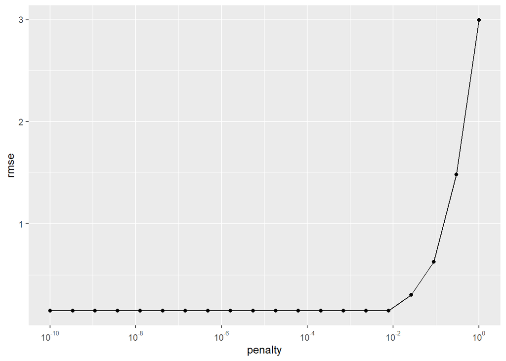

```r
# Visualize rmse vs. penalty
loans_lasso_tune %>%
  collect_metrics() %>%
  filter(.metric == "rmse") %>%
  ggplot(aes(x = penalty, y = mean)) +
  geom_point() +
  geom_line() +
  scale_x_log10(
   breaks = scales::trans_breaks("log10", function(x) 10^x),
   labels = scales::trans_format("log10",scales::math_format(10^.x))) +
  labs(x = "penalty", y = "rmse")
```

```r
loans_lasso_tune %>%
  show_best(metric = "rmse")
```

```
## # A tibble: 5 x 7
##    penalty .metric .estimator  mean     n std_err .config
##      <dbl> <chr>   <chr>      <dbl> <int>   <dbl> <chr>
## 1 1   e-10 rmse    standard   0.149     4 0.00299 Preprocessor1_Model01
## 2 3.36e-10 rmse    standard   0.149     4 0.00299 Preprocessor1_Model02
## 3 1.13e- 9 rmse    standard   0.149     4 0.00299 Preprocessor1_Model03
## 4 3.79e- 9 rmse    standard   0.149     4 0.00299 Preprocessor1_Model04
## 5 1.27e- 8 rmse    standard   0.149     4 0.00299 Preprocessor1_Model05
```

```r
# Best tuning parameter by smallest rmse
best_param <- loans_lasso_tune %>%
  select_best(metric = "rmse")
best_param
```

```
## # A tibble: 1 x 2
##        penalty .config
##          <dbl> <chr>
## 1 0.0000000001 Preprocessor1_Model01
```

```r
# Best tuning parameter by smallest rmse
one_se_param <- loans_lasso_tune %>%
  select_by_one_std_err(metric = "rmse", desc(penalty))
one_se_param
```

```
## # A tibble: 1 x 9
##   penalty .metric .estimator  mean     n std_err .config            .best .bound
##     <dbl> <chr>   <chr>      <dbl> <int>   <dbl> <chr>              <dbl>  <dbl>
## 1 0.00785 rmse    standard   0.149     4 0.00299 Preprocessor1_Mod~ 0.149  0.152
```

```r
loans_lasso_final_wf <- loans_lasso_wf %>%
  finalize_workflow(one_se_param)
loans_lasso_final_wf
```

```
## == Workflow ====================================================================
## Preprocessor: Recipe
## Model: linear_reg()
##
## -- Preprocessor ----------------------------------------------------------------
## 4 Recipe Steps
##
## * step_rm()
## * step_mutate_at()
## * step_dummy()
## * step_normalize()
##
## -- Model -----------------------------------------------------------------------
## Linear Regression Model Specification (regression)
##
## Main Arguments:
##   penalty = 0.00784759970351461
##   mixture = 1
##
## Computational engine: glmnet
```

```r
loans_lasso_final_mod <- loans_lasso_final_wf %>%
  fit(data = loans_training)

loans_lasso_final_mod %>%
  pull_workflow_fit() %>%
  tidy()
```

```
## # A tibble: 98 x 3
##    term                     estimate penalty
##    <chr>                       <dbl>   <dbl>
##  1 (Intercept)              12.3     0.00785
##  2 emp_length                0       0.00785
##  3 annual_income             0       0.00785
##  4 debt_to_income            0.00899 0.00785
##  5 delinq_2y                 0       0.00785
##  6 months_since_last_delinq  0       0.00785
##  7 earliest_credit_line      0       0.00785
##  8 inquiries_last_12m        0       0.00785
##  9 total_credit_lines        0       0.00785
## 10 open_credit_lines         0       0.00785
## # ... with 88 more rows
```

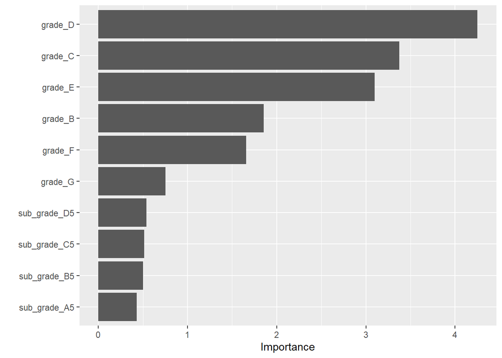

```r
# Visualize variable importance
loans_lasso_final_mod %>%
  pull_workflow_fit() %>%
  vip()
```

```r
# Fit model with best tuning parameter(s) to training data and apply to test data
loans_lasso_test <- loans_lasso_final_wf %>%
  last_fit(loans_split)

# Metrics for model applied to test data
loans_lasso_test %>%
  collect_metrics()
```

```
## # A tibble: 2 x 4
##   .metric .estimator .estimate .config
##   <chr>   <chr>          <dbl> <chr>
## 1 rmse    standard       0.431 Preprocessor1_Model1
## 2 rsq     standard       0.992 Preprocessor1_Model1
```

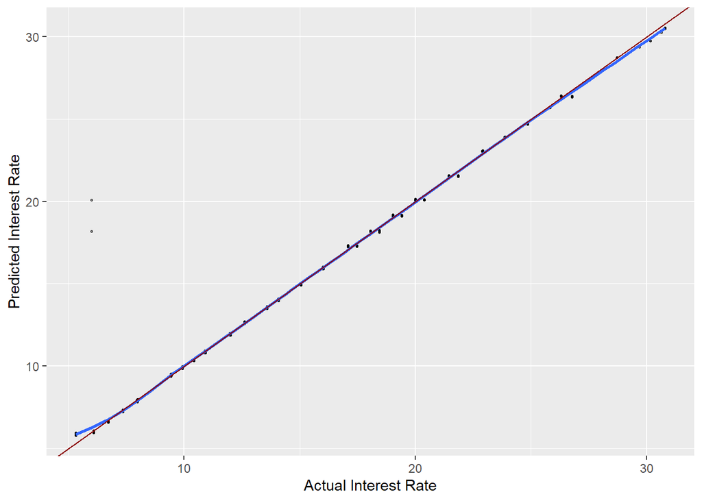

```r
collect_predictions(loans_lasso_test) %>%
  ggplot(aes(x = interest_rate,
             y = .pred)) +
  geom_point(alpha = .5,
             size = .5) +
  geom_smooth(se = FALSE) +
  geom_abline(slope = 1,
              intercept = 0,
              color = "darkred") +
  labs(x = "Actual Interest Rate",
       y = "Predicted Interest Rate")
```

You can see from this graph that the predicted Interest Rates are very close to their actual rates. Thus, this is a good model for predicting our outcome variable. The approach I took was to remove all the jointly filed accounts because those observations contained too many “NA” values. Since I was using “Glmnet” to produce the model, which doesn’t handle “NA” values, I simply got rid of them. In order to fill all the remaining NA values, I mutated all the numeric variables to impute a 0 for each NA. After the pre-processing was finished, I fit the model to the test set, and showed the results (variable importance, RMSE, and Actual vs. Predicted Interest).

## Case #2

```r
customer_orders <- read_csv(file = 'casestudy.csv')
```

```
## * `` -> ...1
```

```r
customer_orders %>%
  group_by(year) %>%
  summarize(total_rev = sum(net_revenue))
```

```
## # A tibble: 3 x 2
##    year total_rev
##   <dbl>     <dbl>
## 1  2015 29036749.
## 2  2016 25730944.
## 3  2017 31417495.
```